# data penjualan mobil bekas

About : Honda car price starts at Rs 6.91 Lakh for the cheapest model which is Amaze and the price of most expensive model, which is City Hybrid eHEV starts at Rs 18.92 Lakh. Honda offers 6 car models in India, including 3 cars in Sedan category, 1 car in Hatchback category, 1 car in Compact SUV category, 1 car in Compact Sedan category. Honda has 2 upcoming cars in India, mid-size SUV and New WR-V. Honda Cars India (HCIL) is a subsidiary of Japanese automobile manufacturer Honda. Founded in 1995, the company has its headquarters located in Greater Noida, Uttar Pradesh. The first model to roll off the company’s production line in India was the City. The model has been on sale in the country for more than 20 years.

Currently, the product portfolio of Honda Cars India includes Amaze, Jazz, WR-V City and all-new City. The City has been the most successful model for the brand in India. HCIL currently produces the aforementioned cars at Tapukara in Rajasthan and closed its plant at Greater Noida in 2021.

For the first 15 years, Honda Cars India offered its products exclusively with petrol engines. In 2013, Honda launched the Amaze compact sedan, which was the first model from the company to be offered with a diesel engine. Currently, the iDTEC engine is offered on all Honda products except the Jazz hatchback.

import library

```python
import pandas as pd  #digunakan untuk library data set
import numpy as np #digunakan untuk data processing
import matplotlib.pyplot as plt # digunakan untuk visualisasi plot
```

Import Data

```python
df= pd.read_csv(r"C:\Users\asus\Desktop\Data Scientist\porto\Honda Used Car Selling\honda_car_selling.csv")
```

```python
df.info()
```

```
<class 'pandas.core.frame.DataFrame'>
RangeIndex: 999 entries, 0 to 998
Data columns (total 6 columns):
 #   Column      Non-Null Count  Dtype
---  ------      --------------  -----
 0   Year        999 non-null    int64
 1   kms Driven  999 non-null    object
 2   Fuel Type   999 non-null    object
 3   Suspension  999 non-null    object
 4   Price       999 non-null    object
 5   Car Model   999 non-null    object
dtypes: int64(1), object(5)
memory usage: 47.0+ KB
```

dari info diatas dapat dilihat tidak ada missing value disana

```python
df
```

|  | Year | kms Driven | Fuel Type | Suspension | Price | Car Model |
| --- | --- | --- | --- | --- | --- | --- |
| 0 | 2019 | 19006 kms | Petrol | Automatic | 9.29 Lakh | Honda City V CVT |
| 1 | 2021 | 11936 kms | Petrol | Automatic | 13.95 Lakh | Honda City ZX CVT |
| 2 | 2018 | 29635 kms | Petrol | Automatic | 9.95 Lakh | Honda City i-VTEC CVT ZX |
| 3 | 2020 | 16163 kms | Petrol | Automatic | 13.26 Lakh | Honda City ZX CVT |
| 4 | 2015 | 105114 kms | Petrol | Manual | 5.68 Lakh | Honda City i VTEC V |
| ... | ... | ... | ... | ... | ... | ... |
| 994 | 2007 | 90000 kms | Petrol | Manual | 1.22 Lakh | Honda Civic 1.8 V MT |
| 995 | 2016 | 31500 kms | Petrol | Manual | 4.25 Lakh | Honda Amaze S i-VTEC |
| 996 | 2017 | 39735 kms | Petrol | Manual | 5.10 Lakh | Honda Amaze S Petrol |
| 997 | 2017 | 36000 kms | Petrol | Manual | 6.10 Lakh | Honda City i VTEC S |
| 998 | 2015 | 35341 kms | Diesel | Manual | 3 Lakh | Honda Amaze S i-Dtech |

999 rows × 6 columns

dari data diatas kita harus memperbaiki nilai pada kms driven (harusnya kms dihilangkan) dan price (lakh kita perbaiki)

```python
def Priceman (value):
    if 'Lakh' in value: #jika ada kata 'Lakh' pada value maka pisahkan pada tanda ' ' (spasi) dan ambil indeks 0 lalu ubah menjadi tipe data float (karena sebelumnya object)
        return float(value.split(' ')[0])
    else:
        #jika tidak ada maka ganti titik menjadi koma dan kali angka tersebut dengan 20535000 (karena 1 lakh sama dengan 20 juta 535 ribu rupiah) ubah jadi numeric dan lalu ke float
        value = value.replace (',', '')
        value = pd.to_numeric(value)
        value = value/100000
        return float(value)
```

```python
#kita membuat fungsi bernama preprocess_inputs
def preprocess_inputs (df):
    # menggunakan data copy untuk menghindari data utama yang rusak
    df = df.copy()
    # merubah tipe data price yang awalnya objt menjadi string
    df['Price'] = df['Price'].str.strip()
    # memasukan value priceIDR ke value price
    df['Price'] = df['Price'].apply(Priceman)

    #kita ubah kolom year menjadi string
    df['Year'] = df['Year'].astype(str)

    # kita hapus kata kms spasi
    df['kms Driven'] = df['kms Driven'].replace ('kms', '')
    #kita hapus spasi
    df['kms Driven'] = df['kms Driven'].str.strip()
    #kita hapus karakter non numeric dan mengubah menjadi ubah menjadi integer
    df['kms Driven'] = df['kms Driven'].replace({'[^0-9]':''},regex=True).astype(int)
    # penjelasan
# [^0-9]: Ini adalah ekspresi reguler yang mencocokkan semua karakter kecuali digit (0 hingga 9).
# .replace({'[^0-9]': ''}, regex=True):
# Fungsi replace digunakan untuk mengganti semua karakter yang cocok dengan pola tersebut dengan string kosong (''), sehingga hanya karakter angka yang tetap.

    # mengembalikan data frame yang sudah diubah
    return df
```

Coba cek hasil fungsi

```python
test = preprocess_inputs(df)
test
```

|  | Year | kms Driven | Fuel Type | Suspension | Price | Car Model |
| --- | --- | --- | --- | --- | --- | --- |
| 0 | 2019 | 19006 | Petrol | Automatic | 9.29 | Honda City V CVT |
| 1 | 2021 | 11936 | Petrol | Automatic | 13.95 | Honda City ZX CVT |
| 2 | 2018 | 29635 | Petrol | Automatic | 9.95 | Honda City i-VTEC CVT ZX |
| 3 | 2020 | 16163 | Petrol | Automatic | 13.26 | Honda City ZX CVT |
| 4 | 2015 | 105114 | Petrol | Manual | 5.68 | Honda City i VTEC V |
| ... | ... | ... | ... | ... | ... | ... |
| 994 | 2007 | 90000 | Petrol | Manual | 1.22 | Honda Civic 1.8 V MT |
| 995 | 2016 | 31500 | Petrol | Manual | 4.25 | Honda Amaze S i-VTEC |
| 996 | 2017 | 39735 | Petrol | Manual | 5.10 | Honda Amaze S Petrol |
| 997 | 2017 | 36000 | Petrol | Manual | 6.10 | Honda City i VTEC S |
| 998 | 2015 | 35341 | Diesel | Manual | 3.00 | Honda Amaze S i-Dtech |

999 rows × 6 columns

```python
test['Price'].max()
```

```
26.5
```

oke sudah bisa kita coba buat visualisasi  
kita coba cek rata rata harga berdasarkan tipe bahan bakar

```
Fuel Type
 CNG        4.210000
 Diesel     5.353632
 Petrol     5.576600
Name: Price, dtype: float64
```

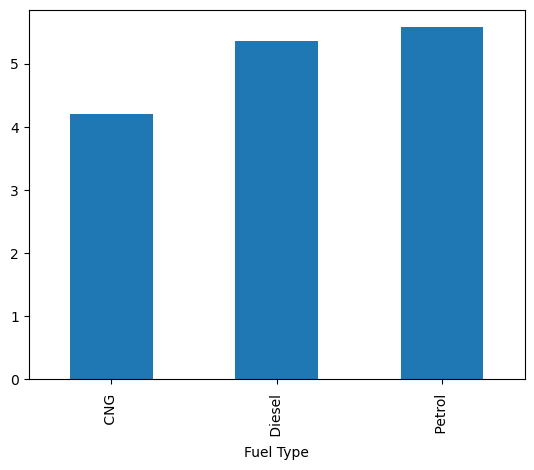

```python
test.groupby ('Fuel Type')['Price'].mean().plot(kind='bar')
test.groupby ('Fuel Type')['Price'].mean()
```

Data diatas menunjukan bahwa bahan bakar dengan jenis petrol secara rata rata lebih tinggi yaitu sebesar 5.57 lakh , diesel 5.35 lakh,  
dan CNG (bahan bakar gas) sebesar 4.21

Kita cek berdasarkan jenis suspensinya yaitu :

```
Suspension
 Automatic    7.662197
 Manual       4.917745
Name: Price, dtype: float64
```

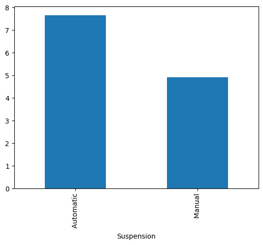

```python
print(test.groupby('Suspension')['Price'].mean())
test.groupby('Suspension')['Price'].mean().plot(kind = 'bar')
```

Kita cek juga mengenai progres rata rata penjualan mobil berdasarkan tahun

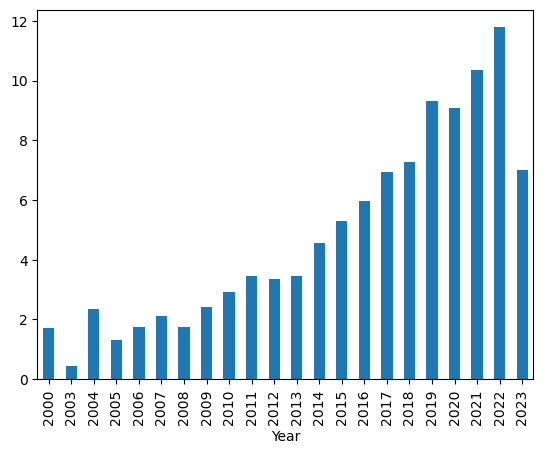

```python
test.groupby('Year')['Price'].mean().plot(kind='bar')
```

data menunjukan bahwa rata rata penjualan cenderung mengalami peningkatan setiap tahunnya

```python
#cek menggunakan len kenapa karena dia menjumlahkan jenis mobil dan pastikan unique
len(test['Car Model'].unique())
```

```
183
```

Total ada 183 jenis mobil yang terjual pada tahun 2000-2023

Karena terlalu banyak, kita coba cek 10 terbesar

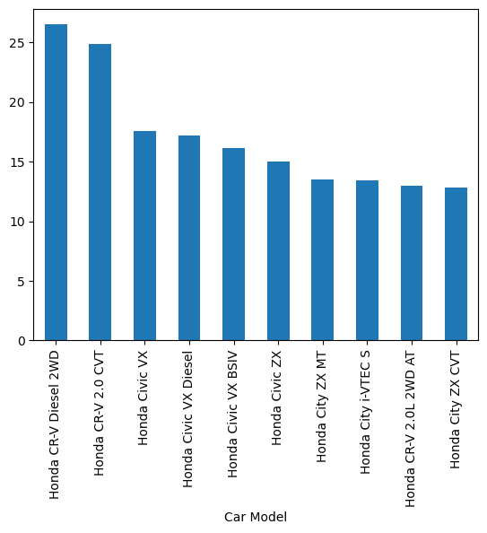

```python
test.groupby('Car Model')['Price'].mean().nlargest(10).plot(kind='bar')
```

data menunjukan 10 rata rata penjualan tertinggi dengan honda crv diesel 2WD dengan lebih dari 25 lakh